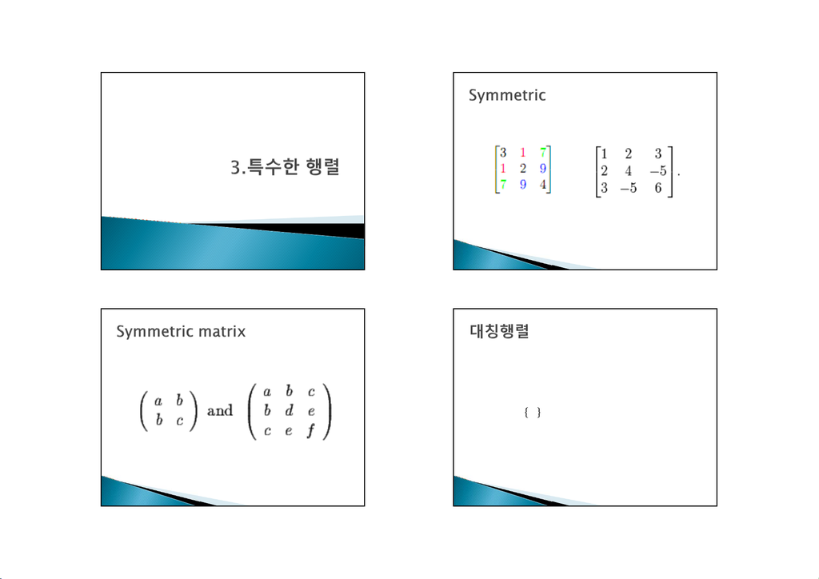

Def. 대칭행렬(symmetric matrix)

𝑹: 대칭행렬

note. 대칭행렬은 정방행렬이다.

[figure not shown]

𝑨, 𝑩: 대칭이고, 𝑨𝑩가 존재할 때,

note. 일반적으로, 대칭행렬들의 곱은 대칭이 아니다.

23

, 𝑩 37

76

에 대하여,

𝑨𝑩  17 19

27 32

homework!! -> 대칭행렬들의 곱이 대칭이 아닌 예

2  2, 3  3

,

: 임의의 행렬에 대하여, 그 행렬의 전치와의 곱은,

항상 존재하고, 대칭이다.

◦예. 𝑨 121

30 1

일때,

210

𝑨𝑨

10 2 2

242

222

참고.

note. 벡터의 외적(outer product)은

반드시 대칭이 되는 건 아니다.

[figure not shown]

예. 𝒙

1

0

2

, 𝒚

2

2

2

, 𝒛 3

2에 대하여,

예. 𝒙

1

0

2

, 𝒚

2

2

2

에 대하여,

1

0

2

, 𝒚

2

2

2

에 대하여,

예. 𝒙

1

0

2

, 𝒛 3

2에 대하여,

[figure not shown]

예. 𝒙

1

0

2

, 𝒛 3

2에 대하여,

Def. 기초벡터(elementary vector; unit vector)

◦𝒆: 단위벡터 ⇔𝑖번째 원소만 1이고, 나머지는 0인벡터

: 𝑖, 𝑗 번째 원소만 1이고, 나머지는 0인행렬

예. 𝒆 0

1, 𝑨 23

57

일때, 𝒆

𝑨 57

, 𝑨𝒆 3

7

대칭행렬 ???

Def. 왜대칭행렬(skew-symmetric matrix)

예.

𝑩

013

1 0 2

320

[figure not shown]

Def. 합벡터(summing vector)

: 모든 원소가 1인벡터, 𝟏 11⋯1

예. 𝒙

1

0

2

, 𝑨 23

57

일때,

𝒙𝟏 102

1

1

1

 3

𝟏𝑨 1123

57

Def. 멱등행렬(idempotent matrix)

예. 𝑴 32

32

,

𝑴 32

32

32

32

32

32

𝑴